# More on nested data frames

03/22/2020

## Remember about subsetting lists

- `x[1]` is a list
  - Something list `x[1:4]` is legitimate and gives a (sub-)list of 4 elements
  - Can also be done by name: `x[“a”]
- `x[[1]]` is a component of a list and removes the top hierarchical level
  - `x[[1:4]]` is not legitimate
- `x$a` is the same as `x[["a"]]`

[figure not shown]

## split-apply-combine

Many tasks in R require the steps of split, apply, and combine

- split data into pieces,
- apply some function to each piece
- combine the results back together

A small example taking advantage of the `modelr` package. We did a similar analysis back in Week 4

```r
library(gapminder)
library(modelr)
gap_us <- gapminder %>% filter(country == "United States") %>%
  mutate(log_gdpPercap = log10(gdpPercap))
gap_us_lm <- lm(log_gdpPercap ~ year, data = gap_us)
```

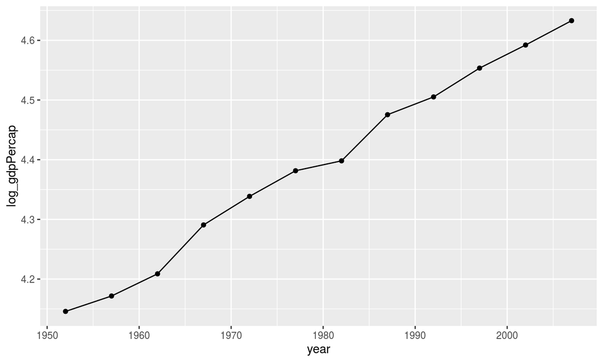

```r
(gap_us_full <- gap_us %>% ggplot(aes(year, log_gdpPercap)) + geom_line() + geom_point())
```

The function `add_predictions()` is from the `modeler` package. You can get something similar using `broom::augment()` as we’ve done in the past.

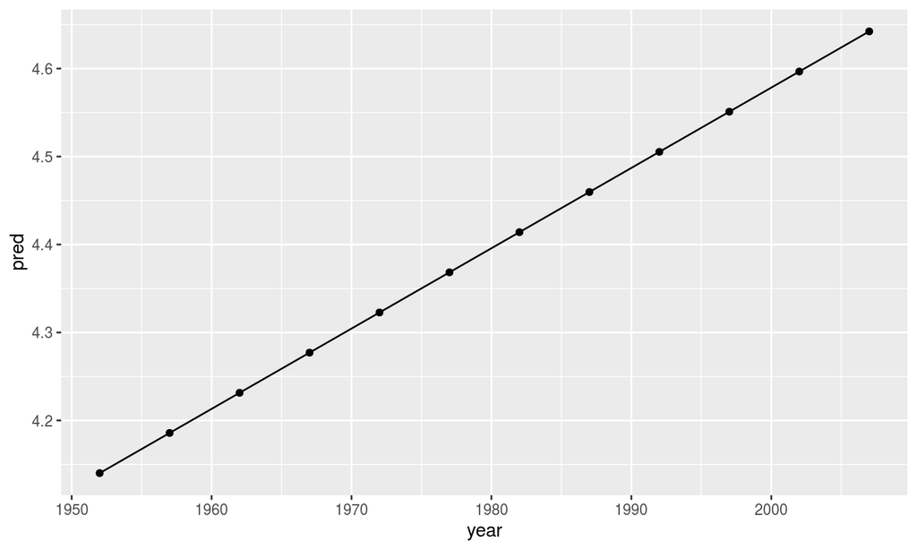

```r
(gap_us_trend <- add_predictions(gap_us, gap_us_lm) %>%
   ggplot(aes(year, pred)) + geom_line() + geom_point() )
```

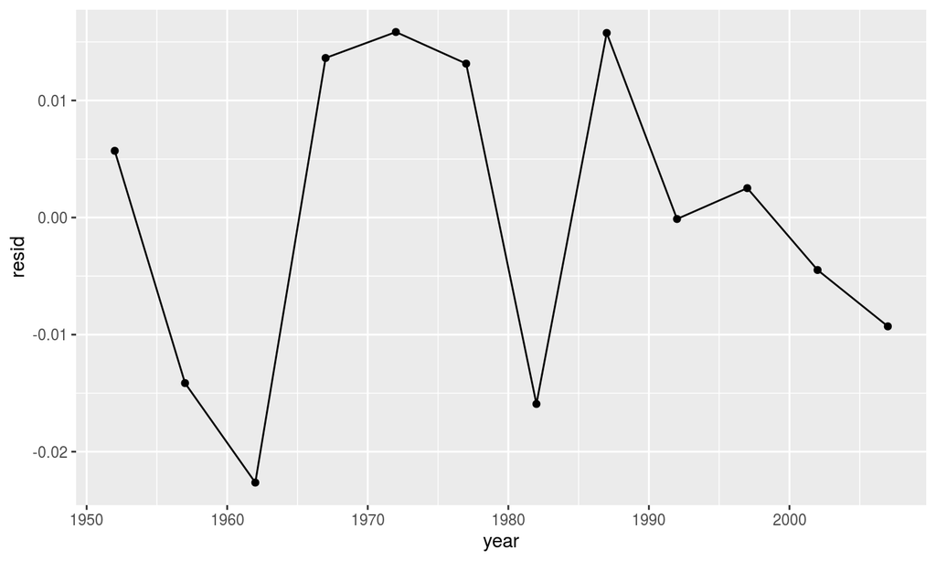

```r
(gap_us_resid <- add_residuals(gap_us, gap_us_lm) %>%
   ggplot(aes(year, resid)) + geom_line() + geom_point() )
```

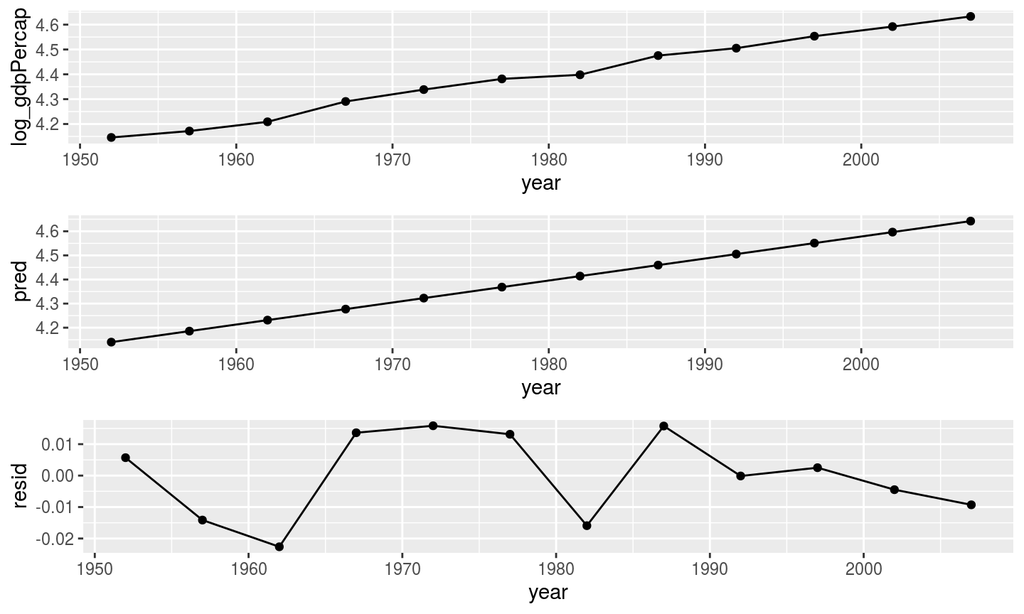

```r
library(gridExtra)
## the package patchwork also works nicely to combine plots
grid.arrange(gap_us_full, gap_us_trend, gap_us_resid, nrow = 3)
```

There are several ways we could apply this sort of analysis to each country, but there is a fairly elegant way using the concept of nested data frames. As we’ve seen, since a data frame is a collection of lists, all of the same length, a column of a data frame could itself contain data frames. This is easily implemented using the `tidyr` package’s `nest()` function.

```r
gap_nested <-   gapminder %>%
    group_by(country, continent) %>%
    nest()
gap_nested[1:3, ]
```

```
## # A tibble: 3 x 3
## # Groups:   country, continent [710]
##   country     continent data
##   <fct>       <fct>     <list>
## 1 Afghanistan Asia      <tibble [12 × 4]>
## 2 Albania     Europe    <tibble [12 × 4]>
## 3 Algeria     Africa    <tibble [12 × 4]>
```

```r
gap_nested[1, "data"]
```

```
## # A tibble: 1 x 1
##   data
##   <list>
## 1 <tibble [12 × 4]>
```

```r
gap_nested$data[[1]]
```

```
## # A tibble: 12 x 4
##     year lifeExp      pop gdpPercap
##    <int>   <dbl>    <int>     <dbl>
##  1  1952    28.8  8425333      779.
##  2  1957    30.3  9240934      821.
##  3  1962    32.0 10267083      853.
##  4  1967    34.0 11537966      836.
##  5  1972    36.1 13079460      740.
##  6  1977    38.4 14880372      786.
##  7  1982    39.9 12881816      978.
##  8  1987    40.8 13867957      852.
##  9  1992    41.7 16317921      649.
## 10  1997    41.8 22227415      635.
## 11  2002    42.1 25268405      727.
## 12  2007    43.8 31889923      975.
```

```r
gap_nested_lm <- gapminder %>% mutate(log_gdpPercap = log10(gdpPercap)) %>%
  group_by(continent, country) %>% nest()
gap_nested_lm[1:3, ]
```

```
## # A tibble: 3 x 3
## # Groups:   country, continent [710]
##   country     continent data
##   <fct>       <fct>     <list>
## 1 Afghanistan Asia      <tibble [12 × 5]>
## 2 Albania     Europe    <tibble [12 × 5]>
## 3 Algeria     Africa    <tibble [12 × 5]>
```

```r
gap_nested_lm[1, "data"]
```

```
## # A tibble: 1 x 1
##   data
##   <list>
## 1 <tibble [12 × 5]>
```

```r
gap_nested_lm$data[[1]] %>% glimpse()
```

```
## Observations: 12
## Variables: 5
## $ year          <int> 1952, 1957, 1962, 1967, 1972, 1977, 1982, 1987, 1992, 1…
## $ lifeExp       <dbl> 28.801, 30.332, 31.997, 34.020, 36.088, 38.438, 39.854,…
## $ pop           <int> 8425333, 9240934, 10267083, 11537966, 13079460, 1488037…
## $ gdpPercap     <dbl> 779.4453, 820.8530, 853.1007, 836.1971, 739.9811, 786.1…
## $ log_gdpPercap <dbl> 2.891786, 2.914265, 2.931000, 2.922309, 2.869221, 2.895…
```

We can define a function to fit a regression model per country

```r
gap_lm <- function(df){
  lm(log_gdpPercap ~ year, data = df)
}
```

We could then use the `map()` function from the `purrr` library to fit a model per country, since `gap_nested_lm$data` is a list:

```r
class(gap_nested_lm$data)
```

```
## [1] "list"
```

```r
gap_all_lm <- gap_nested_lm$data %>% map(gap_lm)
```

```r
class(gap_all_lm)
```

```
## [1] "list"
```

```r
length(gap_all_lm)
```

```
## [1] 142
```

```r
gap_all_lm[[1]]
```

```
##
## Call:
## lm(formula = log_gdpPercap ~ year, data = df)
##
## Coefficients:
## (Intercept)         year
##   3.6963846   -0.0004019
```

Instead, however, let’s put the model right back into the nested data frame:

```r
gap_nested_lm <- gap_nested_lm %>%
  mutate(lm_fit = map(data, gap_lm))

gap_nested_lm
```

```
## # A tibble: 142 x 4
## # Groups:   country, continent [710]
##    country     continent data              lm_fit
##    <fct>       <fct>     <list>            <list>
##  1 Afghanistan Asia      <tibble [12 × 5]> <lm>
##  2 Albania     Europe    <tibble [12 × 5]> <lm>
##  3 Algeria     Africa    <tibble [12 × 5]> <lm>
##  4 Angola      Africa    <tibble [12 × 5]> <lm>
##  5 Argentina   Americas  <tibble [12 × 5]> <lm>
##  6 Australia   Oceania   <tibble [12 × 5]> <lm>
##  7 Austria     Europe    <tibble [12 × 5]> <lm>
##  8 Bahrain     Asia      <tibble [12 × 5]> <lm>
##  9 Bangladesh  Asia      <tibble [12 × 5]> <lm>
## 10 Belgium     Europe    <tibble [12 × 5]> <lm>
## # … with 132 more rows
```

```r
gap_nested_lm$lm_fit[1]
```

```
## [[1]]
##
## Call:
## lm(formula = log_gdpPercap ~ year, data = df)
##
## Coefficients:
## (Intercept)         year
##   3.6963846   -0.0004019
```

Because this is a data frame, we can still do things like `filter()` and `arrange()`. Or `mutate()`.

```r
library(broom)
gap_nested_lm <- gap_nested_lm %>%
  mutate(lm_glance = map(lm_fit, glance))
```

Consider

```r
gap_nested_lm <- gap_nested_lm %>%
  mutate(resid = map2(data, lm_fit, add_residuals))
## Notice map2, not map, because two arguments are indexed

head(gap_nested_lm)
```

```
## # A tibble: 6 x 6
## # Groups:   country, continent [710]
##   country     continent data             lm_fit lm_glance        resid
##   <fct>       <fct>     <list>           <list> <list>           <list>
## 1 Afghanistan Asia      <tibble [12 × 5… <lm>   <tibble [1 × 11… <tibble [12 × …
## 2 Albania     Europe    <tibble [12 × 5… <lm>   <tibble [1 × 11… <tibble [12 × …
## 3 Algeria     Africa    <tibble [12 × 5… <lm>   <tibble [1 × 11… <tibble [12 × …
## 4 Angola      Africa    <tibble [12 × 5… <lm>   <tibble [1 × 11… <tibble [12 × …
## 5 Argentina   Americas  <tibble [12 × 5… <lm>   <tibble [1 × 11… <tibble [12 × …
## 6 Australia   Oceania   <tibble [12 × 5… <lm>   <tibble [1 × 11… <tibble [12 × …
```

At this point, maybe we would like to plot the residuals, or otherwise use them, going back to the original observations. The function `unnest()` will take care of this for us.

```r
gap_unnested <- unnest(gap_nested_lm, resid)
select(gap_unnested, country, year, resid)
```

```
## # A tibble: 1,704 x 4
## # Groups:   country, continent [710]
##    continent country      year    resid
##    <fct>     <fct>       <int>    <dbl>
##  1 Asia      Afghanistan  1952 -0.0202
##  2 Asia      Afghanistan  1957  0.00433
##  3 Asia      Afghanistan  1962  0.0231
##  4 Asia      Afghanistan  1967  0.0164
##  5 Asia      Afghanistan  1972 -0.0347
##  6 Asia      Afghanistan  1977 -0.00641
##  7 Asia      Afghanistan  1982  0.0905
##  8 Asia      Afghanistan  1987  0.0328
##  9 Asia      Afghanistan  1992 -0.0834
## 10 Asia      Afghanistan  1997 -0.0909
## # … with 1,694 more rows
```

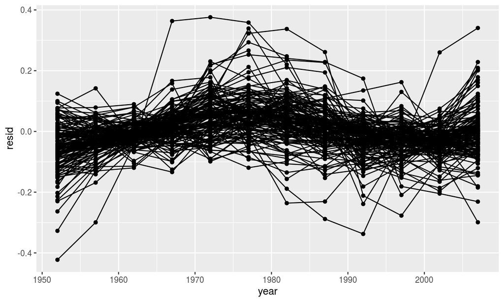

```r
gap_unnested %>% ggplot(aes(year, resid, group = country)) +
  geom_line() +
  geom_point()
```

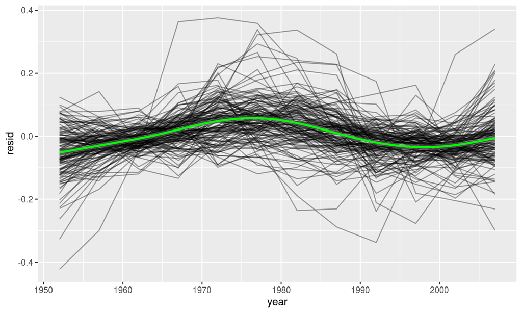

```r
gap_unnested %>% ggplot(aes(year, resid)) +
  geom_line(alpha = 0.375, aes(group = country)) +
  geom_smooth(color = "green")
```

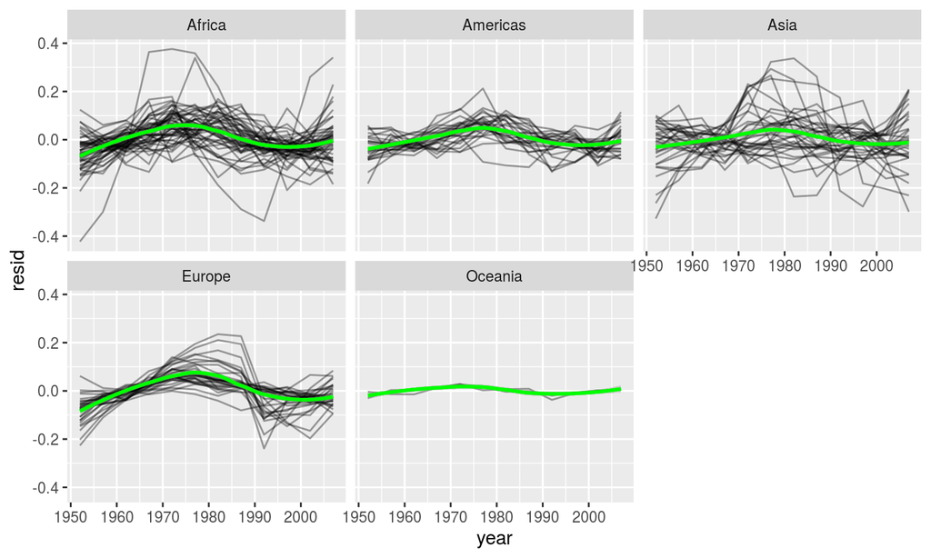

```r
gap_unnested %>% ggplot(aes(year, resid)) +
  geom_line(alpha = 0.375, aes(group = country)) +
  geom_smooth(color = "green") + facet_wrap(~ continent)
```

## An aside on using `walk()` to save lots of files

We could make a set of distinct plots of residuals by continent using `map()`:

```r
continent_residuals <- map(unique(gap_unnested$continent),
    ~ gap_unnested %>%
      filter(continent == .x) %>%
      ggplot(aes(year, resid)) +
        geom_point(alpha = 0.375) +
        geom_smooth(color = "green"))
```

Notice that this is a list of plots. I’m going to add titles using `map2()`:

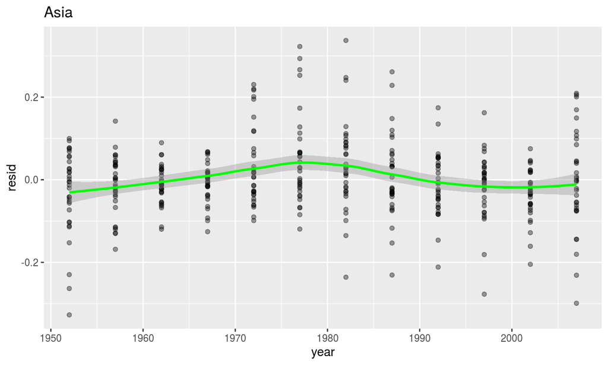

```r
continent_residuals <- map2(unique(gap_unnested$continent), continent_residuals, ~ .y + ggtitle(.x))

continent_residuals[[1]]
```

I did this in preparation to saving the files

```r
walk2(
  paste0(unique(gap_unnested$continent), "-residuals.pdf"),
  continent_residuals,
  ggsave,
  width = 8, height = 6)
```

That code writes out the files

```
Africa-residuals.pdf
Americas-residuals.pdf
Asia-residuals.pdf
Europe-residuals.pdf
Oceania-residuals.pdf
```

```r
gap_glance <- gap_nested_lm %>%
  unnest(lm_glance, .drop = TRUE)
print(head(gap_glance), width = Inf)
```

```
## # A tibble: 6 x 16
## # Groups:   country, continent [710]
##   country     continent data              lm_fit r.squared adj.r.squared  sigma
##   <fct>       <fct>     <list>            <list>     <dbl>         <dbl>  <dbl>
## 1 Afghanistan Asia      <tibble [12 × 5]> <lm>      0.0151       -0.0834 0.0614
## 2 Albania     Europe    <tibble [12 × 5]> <lm>      0.708         0.679  0.0896
## 3 Algeria     Africa    <tibble [12 × 5]> <lm>      0.779         0.757  0.0703
## 4 Angola      Africa    <tibble [12 × 5]> <lm>      0.165         0.0819 0.131
## 5 Argentina   Americas  <tibble [12 × 5]> <lm>      0.726         0.699  0.0502
## 6 Australia   Oceania   <tibble [12 × 5]> <lm>      0.994         0.993  0.0146
##   statistic  p.value    df logLik   AIC    BIC deviance df.residual
##       <dbl>    <dbl> <int>  <dbl> <dbl>  <dbl>    <dbl>       <int>
## 1     0.153 7.04e- 1     2  17.6  -29.1 -27.7   0.0377           10
## 2    24.3   5.96e- 4     2  13.0  -20.0 -18.6   0.0803           10
## 3    35.3   1.43e- 4     2  15.9  -25.8 -24.4   0.0494           10
## 4     1.98  1.90e- 1     2   8.48 -11.0  -9.51  0.171            10
## 5    26.5   4.30e- 4     2  20.0  -33.9 -32.5   0.0252           10
## 6  1556.    2.62e-12     2  34.8  -63.6 -62.2   0.00212          10
##   resid
##   <list>
## 1 <tibble [12 × 6]>
## 2 <tibble [12 × 6]>
## 3 <tibble [12 × 6]>
## 4 <tibble [12 × 6]>
## 5 <tibble [12 × 6]>
## 6 <tibble [12 × 6]>
```

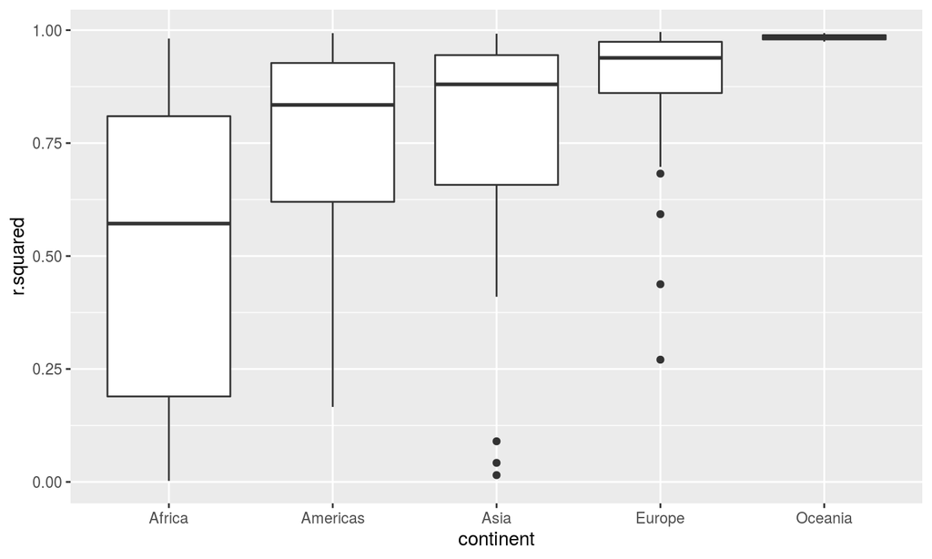

```r
gap_glance %>%
  ggplot(aes(continent, r.squared)) +
  geom_boxplot()
```

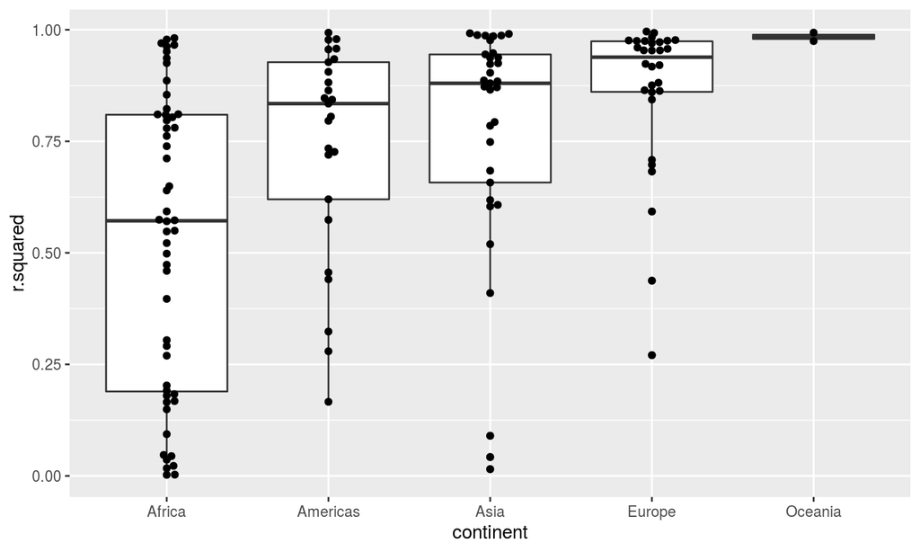

```r
library(ggbeeswarm)
gap_glance %>%
  ggplot(aes(continent, r.squared)) +
  geom_boxplot() +
  geom_beeswarm()
```

Let’s look at the worst fitting countries

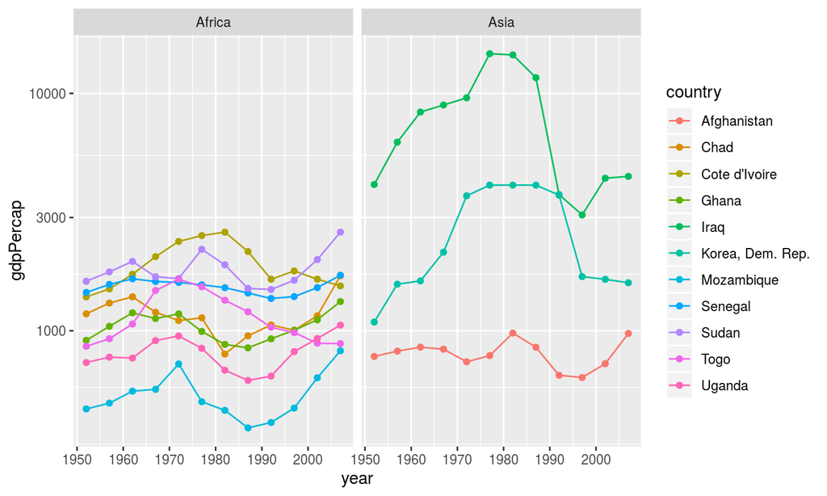

```r
gap_bad_fit <- filter(gap_glance, r.squared < 0.125)

gapminder %>% semi_join(gap_bad_fit, by = "country") %>%
  ggplot(aes(year, gdpPercap, colour = country)) +
    geom_line() + geom_point() +
  scale_y_log10() +  facet_wrap(~ continent)
```

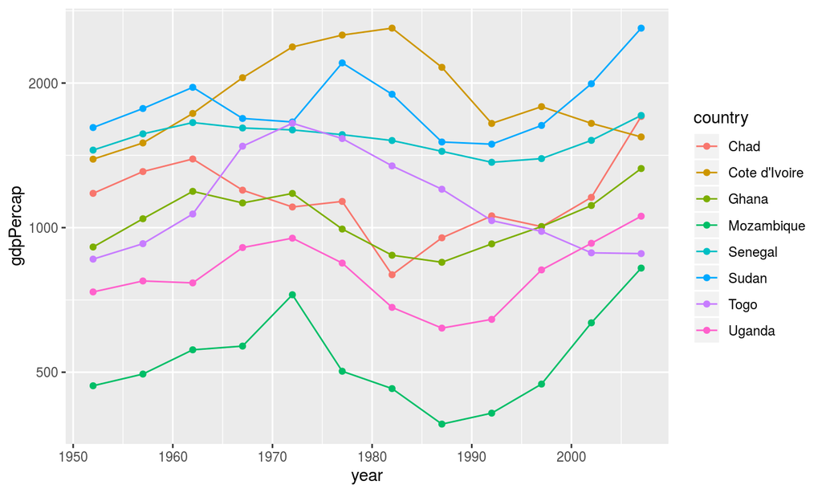

```r
gapminder %>% semi_join(gap_bad_fit, by = "country") %>%
  filter(continent == "Africa") %>%
  ggplot(aes(year, gdpPercap, colour = country)) +
    geom_line() + geom_point() + scale_y_log10()
```

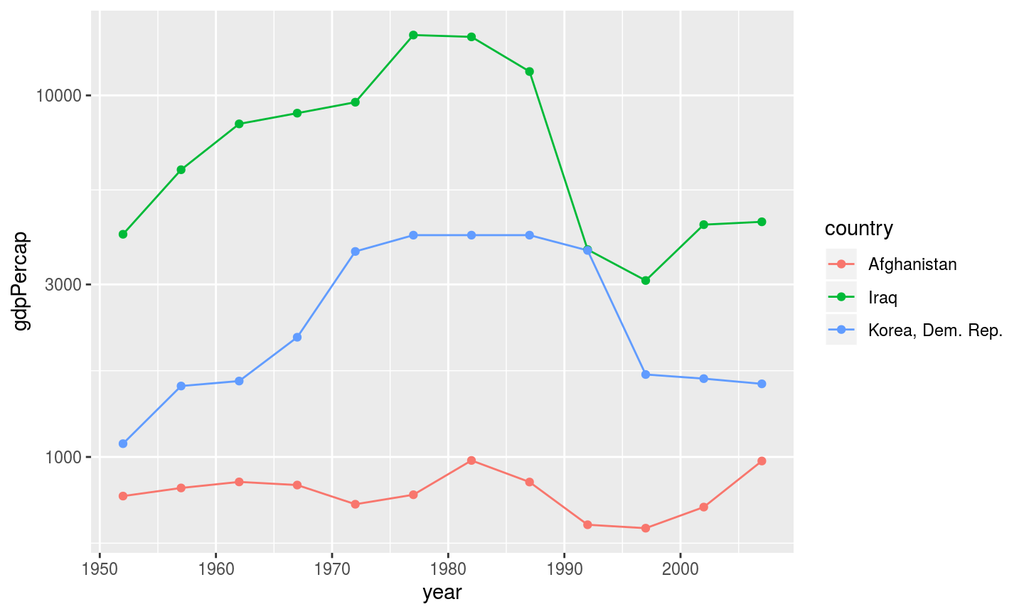

```r
gapminder %>% semi_join(gap_bad_fit, by = "country") %>%
  filter(continent == "Asia") %>%
  ggplot(aes(year, gdpPercap, colour = country)) +
    geom_line() + geom_point() + scale_y_log10()
```

## High level view

- If all you need to do is calculate a single number per group, then `group_by()` and `summarize()` should do the trick
- The use of `nest()` is needed for more general group-wise computation
- Typically do not want list-columns as the final product, since they are rather awkward
- The results here could have been done by other approaches, but this approach is both simple and powerful

## In class exercise

- load the `repurrrsive` package and run this code:

```r
library(repurrrsive)
```

```r
GoT <- tibble(
  name = got_chars %>% map_chr("name"),
  aliases = got_chars %>% map("aliases"),
  allegiances = got_chars %>% map("allegiances")
)
```

- create a new logical variable in the tibble, corresponding to whether or not “Lannister” is in the allegiances column
- Keep only those rows for which the new variable is TRUE, drop the allegiances column, and use `unnest()` to get a data frame with characters with allegiance to the Lannisters along with their aliases

## An example for cross-validation

```r
iris.cv <- iris %>%
  crossv_kfold(k = 10)
head(iris.cv)
```

```
## # A tibble: 6 x 3
##   train        test         .id
##   <named list> <named list> <chr>
## 1 <resample>   <resample>   01
## 2 <resample>   <resample>   02
## 3 <resample>   <resample>   03
## 4 <resample>   <resample>   04
## 5 <resample>   <resample>   05
## 6 <resample>   <resample>   06
```

`crossv_kfold()` is part of the `modelr` package

```r
iris.cv <- iris.cv %>%
  mutate(model = map(train, ~lm(Sepal.Length ~ Petal.Length, data=.)))
head(iris.cv)
```

```
## # A tibble: 6 x 4
##   train        test         .id   model
##   <named list> <named list> <chr> <named list>
## 1 <resample>   <resample>   01    <lm>
## 2 <resample>   <resample>   02    <lm>
## 3 <resample>   <resample>   03    <lm>
## 4 <resample>   <resample>   04    <lm>
## 5 <resample>   <resample>   05    <lm>
## 6 <resample>   <resample>   06    <lm>
```

```r
library(magrittr) ## we want to use %$%
iris.cv %$%
  map2_dbl(model, test, rmse)
```

```
##         1         2         3         4         5         6         7         8
## 0.4367119 0.5459599 0.3448544 0.4092139 0.3564949 0.4105912 0.4312326 0.3253587
##         9        10
## 0.3212595 0.4608004
```

```r
# rmse is part of the modelr package
```

We could have done it all in a single (extended) line

```r
iris %>%
  crossv_kfold(10) %>%
  mutate(model = map(train, ~lm(Sepal.Length ~ Petal.Length, data=.))) %$%
  map2_dbl(model, test, rmse)
```

```
##         1         2         3         4         5         6         7         8
## 0.4947247 0.3410777 0.5466282 0.4094668 0.3565539 0.4328722 0.4053580 0.3523178
##         9        10
## 0.3146702 0.3769736
```

Jenny Bryan has an edifying and amusing [slide deck on this subject](https://speakerdeck.com/player/907f3dc0cdb5496c8d35efca70e5f6bd?#)